# Faiza_Anan_Noor_DAKD_2023_exercise_3

### Fill in your name, student id number and email address

#### Name: Faiza Anan Noor

#### Student id: 2306676

#### Email: fanoor@utu.fi

## Data analysis and knowledge discovery - Exercise 3: Unsupervised learning

This is the template for the third exercise. The purpose of this exercise is to familiarize yourself with the basics of unsupervised learning by using the agglomerative hierarchical clustering and k-means clustering algorithms to find patterns.

This exercise uses the wine dataset, available on moodle as `ex3_wine.csv`. The features are all numeric. They quantify chemical properties of wine, grown around the same area in Italy. The feature names are listed in the table below.

| Feature | Type |
| --- | --- |
| Alcohol | Numeric (float) |
| Malic acid | Numeric (float) |
| Ash | Numeric (float) |
| Alcalinity of ash | Numeric (float) |
| Magnesium | Numeric (integer) |
| Total phenols | Numeric (float) |
| Flavanoids | Numeric (float) |
| Nonflavanoid phenols | Numeric (float) |
| Proanthocyanins | Numeric (float) |
| Color intensity | Numeric (float) |
| Hue | Numeric (float) |
| OD280/OD315 of diluted wines | Numeric (float) |
| Proline | Numeric (integer) |

In real applications, visualizing various aspects of the data the data and data scrubbing are important steps. However, in this exercise you can treat the data as given, and focus on the unsupervised methods.

Please consider the following things when returning your notebook:

- As in the two previous exercises, the grading scale is failed/passed/passed with honors.
- **For a passing grade, Parts 1-3 must be complete**, and all questions in each of them should be answered. Some mistakes are allowed as long as you clearly attempt to solve all the exercises.
- For completing Parts 1-3 and the optional bonus Part 4 sufficiently well, you will be awarded one bonus point for the exam.
- All the cells in the finished notebook should run without crashing. Please delete unnecessary cells. As a good rule of thumb, use **"Restart Kernel and Run All Cells"** on your finished notebook to make sure it runs without errors and produces the expected output.
- Comment your code to explain how it works and what you intend for it to do.
- Answer the questions asked in the assignments in Markdown cells.
- If you're having trouble with this exercise, try an online search first, but **don't just copy-paste code you find**. See exercise guidelines in the Moodle page of this course. If you can't find a solution to your problem, **ask for advice at the exercise sessions** or in the course discussion forum on Moodle or email oskari.s.heikkinen@utu.fi.
- If/when you look things up during this exercise, please **cite your sources**, e.g. a link to a web page. It's better to cite too much than too little.
- **We don't encourage using a large language model (LLM) such as ChatGPT while doing these exercises.** However, if you do use an LLM, be critical of its output. Understand any code the LLM produced before using the code, don't just copy-paste it. If you used one, write a short description of how you used the LLM in the context of these exercises (what was your input, how did you benefit from the output?)

```python
import os
os.environ['OMP_NUM_THREADS'] = '1'
import warnings
warnings.filterwarnings('ignore')
```

### Library imports, Jupyter Notebook settings etc.

The below libraries are sufficient to complete the exercise. You can import additional modules here if you want.

```python
import itertools # has some utilities that may be useful in the exercise

import matplotlib
import numpy as np
import pandas as pd
import matplotlib.pyplot as plt
from matplotlib.patches import Ellipse
from sklearn.preprocessing import StandardScaler
from sklearn.decomposition import PCA
from sklearn.cluster import AgglomerativeClustering, KMeans
from sklearn.metrics import silhouette_score, adjusted_rand_score
from scipy.cluster.hierarchy import linkage, dendrogram
from sklearn.decomposition import PCA
import scipy.cluster.hierarchy as sch
from sklearn.preprocessing import LabelEncoder
# IPython magic command to display matplotlib figures together with the output
# (Often the default setting in a Jupyter Notebook context, so your figures probably work fine without it)
%matplotlib inline
```

### Part 0: Read the data

- Download the exercise 3 data on the Moodle page of this course. (`ex3_wine.csv`)
- Read the data into a Pandas dataframe.
- Display a few rows and some basic information to make sure the data was loaded correctly

I have Downloaded the exercise 3 data on the Moodle page of this course. (ex3_wine.csv) & read the data into a Pandas dataframe. We also displayed a few rows and some basic information to make sure the data was loaded correctly

```python
df_wine=pd.read_csv("ex3_wine.csv")
df_wine.head(4)
```

|  | Alcohol | Malic_Acid | Ash | Ash_Alcanity | Magnesium | Total_Phenols | Flavanoids | Nonflavanoid_Phenols | Proanthocyanins | Color_Intensity | Hue | OD280 | Proline |
| --- | --- | --- | --- | --- | --- | --- | --- | --- | --- | --- | --- | --- | --- |
| 0 | 14.23 | 1.71 | 2.43 | 15.6 | 127 | 2.80 | 3.06 | 0.28 | 2.29 | 5.64 | 1.04 | 3.92 | 1065 |
| 1 | 13.20 | 1.78 | 2.14 | 11.2 | 100 | 2.65 | 2.76 | 0.26 | 1.28 | 4.38 | 1.05 | 3.40 | 1050 |
| 2 | 13.16 | 2.36 | 2.67 | 18.6 | 101 | 2.80 | 3.24 | 0.30 | 2.81 | 5.68 | 1.03 | 3.17 | 1185 |
| 3 | 14.37 | 1.95 | 2.50 | 16.8 | 113 | 3.85 | 3.49 | 0.24 | 2.18 | 7.80 | 0.86 | 3.45 | 1480 |

### Part 1: Preprocess and visualize the data

- Perform z-score standardization on the features to ensure that all features have the same scale.
- Project the data to two dimensions by using principal component analysis (PCA) and visualize the resulting two-dimensional data in a scatter plot. Don't color the scatter plot yet.
- Does it look like there are clear clusters? Don't worry if they're hard to see. There may be more than one "correct" answer.
- Draw shapes (for example `matplotlib.patches.Ellipse`) on top of the scatter plot to visualize any clusters you feel you can easily detect.

First, we perform z-score standardization on the features to ensure that all features have the same scale.

```python
scaler = StandardScaler()
scaled_df_wine = pd.DataFrame(scaler.fit_transform(df_wine), columns=df_wine.columns)
scaled_df_wine.head(4)
```

|  | Alcohol | Malic_Acid | Ash | Ash_Alcanity | Magnesium | Total_Phenols | Flavanoids | Nonflavanoid_Phenols | Proanthocyanins | Color_Intensity | Hue | OD280 | Proline |
| --- | --- | --- | --- | --- | --- | --- | --- | --- | --- | --- | --- | --- | --- |
| 0 | 1.518613 | -0.562250 | 0.232053 | -1.169593 | 1.913905 | 0.808997 | 1.034819 | -0.659563 | 1.224884 | 0.251717 | 0.362177 | 1.847920 | 1.013009 |
| 1 | 0.246290 | -0.499413 | -0.827996 | -2.490847 | 0.018145 | 0.568648 | 0.733629 | -0.820719 | -0.544721 | -0.293321 | 0.406051 | 1.113449 | 0.965242 |
| 2 | 0.196879 | 0.021231 | 1.109334 | -0.268738 | 0.088358 | 0.808997 | 1.215533 | -0.498407 | 2.135968 | 0.269020 | 0.318304 | 0.788587 | 1.395148 |
| 3 | 1.691550 | -0.346811 | 0.487926 | -0.809251 | 0.930918 | 2.491446 | 1.466525 | -0.981875 | 1.032155 | 1.186068 | -0.427544 | 1.184071 | 2.334574 |

Then we project the data to two dimensions by using principal component analysis (PCA).

```python
from sklearn.decomposition import PCA
pca = PCA(n_components=2)
#principal_components now has the reduced data
principal_components = pca.fit_transform(scaled_df_wine)
#principal_components
```

And then, visualize the resulting two-dimensional data in a scatter plot. We don't color the scatter plot yet.

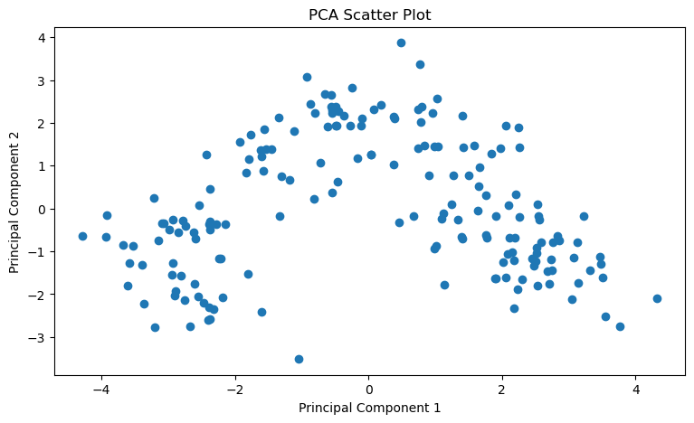

```python
plt.figure(figsize=(9, 5))
plt.scatter(principal_components[:, 0], principal_components[:, 1])
plt.xlabel('Principal Component 1')
plt.ylabel('Principal Component 2')
plt.title('PCA Scatter Plot')
plt.show()
```

Detecting clusters visually can be subjective. You can use methods like K-means clustering or density-based clustering algorithms to find clusters. However, to visually represent clusters, you might draw shapes or ellipses to highlight potential clusters.

Now we will examine if there are clusters in the data points.

I did it first manually by analyzing the data points visually and later on I used a clustering algorithm(K means in my case). The following is the marking of the 3 clusters manually.

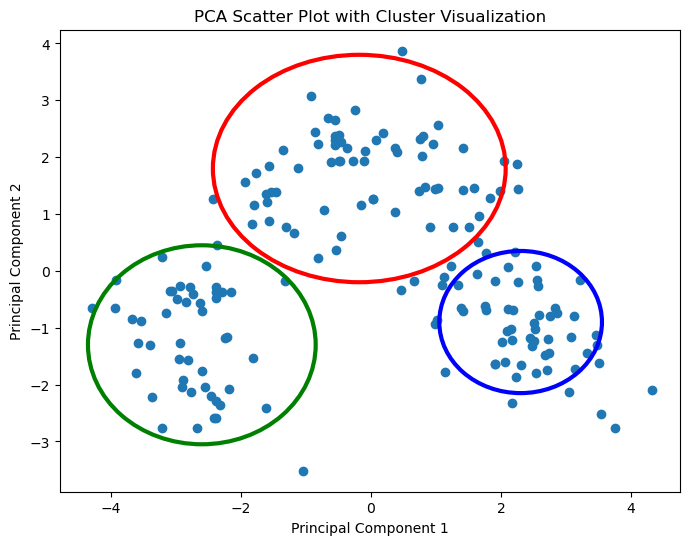

```python
plt.figure(figsize=(8, 6))
plt.scatter(principal_components[:, 0], principal_components[:, 1])

# Define ellipse parameters for the first cluster
ellipse1 = Ellipse(xy=(-0.18,  1.8), width=4.5, height=4, edgecolor='r', fc='None', lw=3)
plt.gca().add_patch(ellipse1)

# Define ellipse parameters for the second cluster
ellipse2 = Ellipse(xy=( 2.3, -0.9), width=2.5, height=2.5, edgecolor='b', fc='None', lw=3)
plt.gca().add_patch(ellipse2)

# Define ellipse parameters for the third cluster
ellipse3 = Ellipse(xy=( -2.6, -1.3), width=3.5, height=3.5, edgecolor='g', fc='None', lw=3)
plt.gca().add_patch(ellipse3)

plt.xlabel('Principal Component 1')
plt.ylabel('Principal Component 2')
plt.title('PCA Scatter Plot with Cluster Visualization')
plt.show()
```

In the code snippet below, I used K-means clustering with k=3 to cluster my data into 3 points.

```python
# Clustering - K-means as an example
k=3
kmeans1 = KMeans(n_clusters=k)
kmeans1.fit(principal_components)
cluster_centers1 = kmeans1.cluster_centers_
print("The cluster centers for the points are : ")

for i, val in enumerate(cluster_centers1):
    print("Cluster ",i,": ", val )
```

```
The cluster centers for the points are :
Cluster  0 :  [ 2.26614991 -0.86559213]
Cluster  1 :  [-0.16278513  1.76758824]
Cluster  2 :  [-2.74392982 -1.2141906 ]
```

```python
cluster_labels1=kmeans1.labels_
```

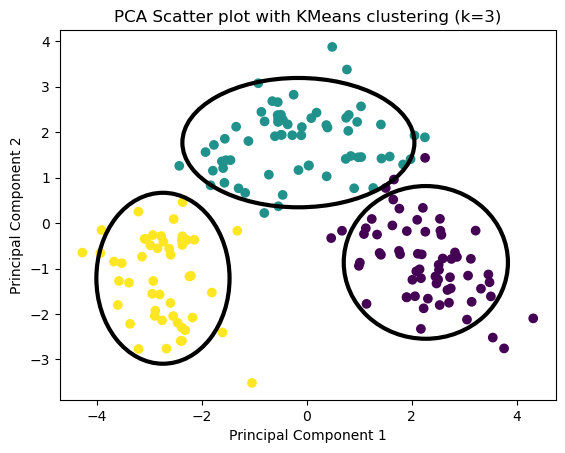

```python
# Scatter plotting of PCA-reduced data with predicted clusters
plt.scatter(principal_components[:, 0], principal_components[:, 1], c=cluster_labels1, cmap='viridis', alpha=1)

# Drawing ellipses around each cluster
for cluster in range(k):
    cluster_indices = np.where(cluster_labels1 == cluster)[0]
    cluster_data1 = principal_components[cluster_indices]

    ellipse = Ellipse(xy=(np.mean(cluster_data1[:, 0]), np.mean(cluster_data1[:, 1])),
                      width=np.std(cluster_data1[:, 0])*4, height=np.std(cluster_data1[:, 1])*4,
                      edgecolor='black', fc='None', lw=3)

    plt.gca().add_patch(ellipse)

plt.xlabel('Principal Component 1')
plt.ylabel('Principal Component 2')
plt.title(f'PCA Scatter plot with KMeans clustering (k={k})')
plt.show()
```

### Part 2a: Agglomerative hierarchical clustering

- Cluster the data into 2-10 clusters using agglomerative hierarchical clustering.
- Try different values for the linkage parameter. (Ward, Single, Average and Complete)
- Use the z-score standardized 13-dimensional data for clustering - **don't use the first two principal components for clustering!**
- Explain why using the two principal components would be a bad idea for clustering.
- Using silhouette score, evaluate the clustering performance for each linkage criterion and number of clusters combination. Sort the results by silhouette score.
- Plot the data into a scatter plot again, this time colouring the data points according to the cluster they were assigned to. Use the best 6 clusterings according to silhouette score.
- Do some of the clusterings discovered by agglomerative hierarchical clustering correspond to what visually looked like clusters to you in Part 1? It's absolutely fine if they don't.

*Tip: you can use `itertools.product` function to get the Cartesian product of the two lists of hyperparameters (number of clusters, linkage criterion)*

*Note: it's a common mistake to think that the points in the scatter plot should move when clustering, but they should not. Clustering can be visualized simply by colouring data points on an existing plot.*

We cluster the data into 2-10 clusters using agglomerative hierarchical clustering & try different values for the linkage parameter. (Ward, Single, Average and Complete)

```python
# Different values for the linkage parameter. (Ward, Single, Average and Complete)
linkage_methods = ['ward', 'single', 'average', 'complete']

# We clustering the data into 2-10 clusters using agglomerative hierarchical clustering
cluster_range = range(2, 11)
results = []
```

```python
# We used the z-score standardized 13-dimensional data for clustering(scaled_df_wine)
for linkage in linkage_methods:
    for n_clusters in cluster_range:
        # Perform clustering using AgglomerativeClustering(
        clustering = AgglomerativeClustering(n_clusters=n_clusters, linkage=linkage)
        cluster_labels = clustering.fit_predict(scaled_df_wine)

        # Calculate silhouette score
        silhouette_avg = silhouette_score(scaled_df_wine, cluster_labels)
        results.append({
            'Linkage': linkage,
            'Clusters': n_clusters,
            'Silhouette Score': silhouette_avg,
            'Cluster Labels': cluster_labels
        })
```

### Why Using Principal Components for Clustering Might Be a Bad Idea *

Using principal components for clustering might not be ideal because principal components are derived to maximize variance and might not always capture the most relevant information for clustering. They might discard information relevant for clustering from other dimensions.

Using silhouette score, we evaluate the clustering performance for each linkage criterion and number of clusters combination. & sort the results by silhouette score.

```python
# Sorting results by silhouette score
results = sorted(results, key=lambda x: x['Silhouette Score'], reverse=True)
# Selecting the best six results based on silhouette score
# Here, 'best_six_results' contains the best six clustering results

best_six_results = results[:6]
```

Then we plot the data into a scatter plot again, this time colouring the data points according to the cluster they were assigned to. Use the best 6 clusterings according to silhouette score.

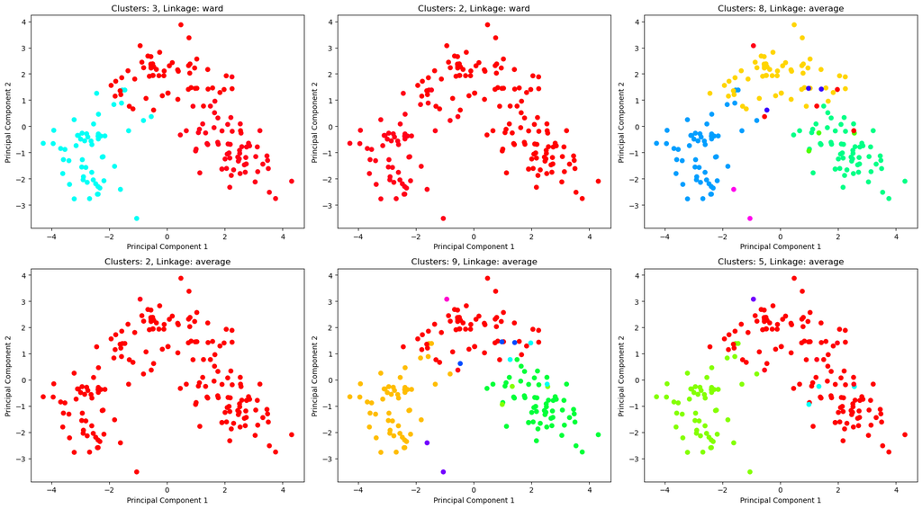

```python
# Here, 'best_six_results' contains the best six clustering results

plt.figure(figsize=(18, 10))
for idx, result in enumerate(best_six_results):
    plt.subplot(2, 3, idx + 1)
    plt.scatter(principal_components[:, 0], principal_components[:, 1], c=result['Cluster Labels'], cmap='hsv')
    plt.title(f"Clusters: {result['Clusters']}, Linkage: {result['Linkage']}")
    plt.xlabel('Principal Component 1')
    plt.ylabel('Principal Component 2')
plt.tight_layout()
plt.show()
```

#### Some of the clusterings discovered by agglomerative hierarchical clustering correspond to what visually looked like clusters to my ones in Part 1. For example,

The Cluster 9(Linkage: Average) and Cluster 8(Linkage: Average) greatly resembles both my manually done and K means cluster algorithm results in Part 1 as they yielded 3 clusters almost like them

### Part 2b: Dendrograms

- Plot dendrograms to visualize the merging processes.
- For this you will need a linkage matrix. *Hint: while you can extract one from a fitted AgglomerativeClustering object, it is much easier to use the scipy implementation (`scipy.cluster.hierarchy.linkage`).*
- Compute the linkage matrix using Ward and Single linkage, and plot the dendrograms using `scipy.cluster.hierarchy.dendrogram`.
- Truncate the dendrogram for better readability. You may choose how exactly you want to do the truncation.
- How do you interpret the dendrograms? How do they differ?

*Note: when truncating a dendrogram, a number in parentheses refers to the amount of samples in a subtree. A number without parentheses is the index of a single sample*

Then we plot dendrograms to visualize the merging processes.

#### For this we will need a linkage matrix and used the scipy implementation (scipy.cluster.hierarchy.linkage).

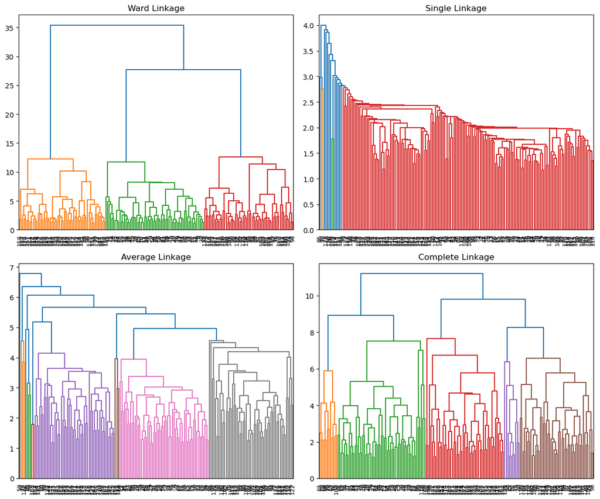

```python
linkages = [sch.linkage(scaled_df_wine, method=method) for method in linkage_methods]

# Plot dendrograms in a 2x2 layout
fig, axs = plt.subplots(2, 2, figsize=(12, 10))

for i, linkage, method in zip(range(4), linkages, linkage_methods):
    plt.subplot(2, 2, i+1)
    dendrogram(linkage,  leaf_font_size=8)
    plt.title(f'{method.capitalize()} Linkage')

plt.tight_layout()
plt.show()
```

Then we truncate the dendrogram for better readability. We have done this truncation in dendrograms by cutting off or collapsing branches to focus on a specific range of clusters. This can be achieved by adjusting the truncate_mode and p parameters in scipy.cluster.hierarchy.dendrogram.

```
truncate_mode='lastp': Truncates the dendrogram by displaying only the last p merged clusters.
p: Specifies the number of clusters to show at the end of the dendrogram.
```

#### Then we compute the linkage matrix using Ward and Single linkage, and plot the dendrograms using scipy.cluster.hierarchy.dendrogram.

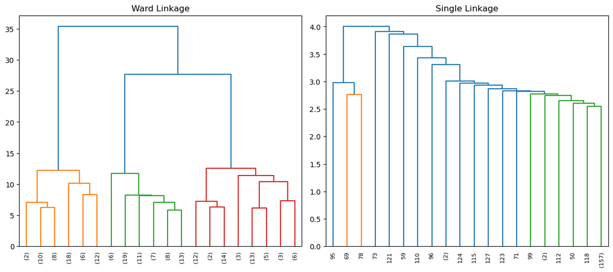

```python
methods_2 = ['ward', 'single']
linkages_2 = [sch.linkage(scaled_df_wine, method=method) for method in methods_2]

# Plot dendrograms in a 2x2 layout
fig, axs = plt.subplots(1, 2, figsize=(12, 10))

for i, linkage, method in zip(range(2), linkages_2, methods_2):
    plt.subplot(2, 2, i+1)
    sch.dendrogram(linkage, truncate_mode='lastp', p=20, leaf_rotation=90, leaf_font_size=8)
    plt.title(f'{method.capitalize()} Linkage')

plt.tight_layout()
plt.show()
```

Then we tried to interpret the dendrograms.

It is seen that Ward dendograms focuses on compact, well-separated clusters. And Single dendograms emphasizes chains or elongated clusters(not as well separated), more sensitive to outliers.

Whereas single linkage searches for the points that are closest to clusters, sometimes resulting in longer or less cohesive groups, ward linkage concentrates on limiting variation to create compact, evenly sized clusters.

Compare the clustering results obtained using silhouette scores and visualize them in separate scatter plots colored according to the assigned clusters. These clusters might or might not align with the visual clusters identified in the previous steps.

Agglomerative hierarchical clustering uses different linkage methods that may form clusters differently based on how they calculate distances between clusters. The evaluation via silhouette scores helps in selecting the best clustering results based on the chosen linkage and cluster size.

### Part 3: *k*-means clustering

- Perform *k*-means clustering on the data. Try 2-10 numbers of clusters.
- Evaluate the clustering performance using silhouette score.
- Choose the best 3 numbers of clusters according to silhouette score that you discovered above, and once again visualize them on a scatter plot of the first two principal components.
- Display the centroids of the clusters on the plot. Remember to transform the centroids to the PCA space. Explain why you need to transform the centroids.

```python
# Initializing variables to store silhouette scores and selected clusters
silhouette_scores = []
best_three_clusters2 = []
```

```python
# Performing k-means clustering on the data. We try 2-10 numbers of clusters

for n_clusters in range(2, 11):
    kmeans = KMeans(n_clusters=n_clusters)
    cluster_labels = kmeans.fit_predict(scaled_df_wine)

    # Evaluating the clustering performance using silhouette score.
    silhouette_avg = silhouette_score(scaled_df_wine, cluster_labels)
    silhouette_scores.append((n_clusters, silhouette_avg))
```

```python
# Sorting silhouette scores in descending order and selecting top three clusters
sorted_scores = sorted(silhouette_scores, key=lambda x: x[1], reverse=True)
for i in range(3):
    best_three_clusters2.append(sorted_scores[i][0])

print("Best 3 clusters are :", best_three_clusters2)
```

```
Best 3 clusters are : [3, 2, 4]
```

```python
# Use PCA to reduce dimensions to 2 components
pca = PCA(n_components=2)
transformed_data2 = pca.fit_transform(scaled_df_wine)
```

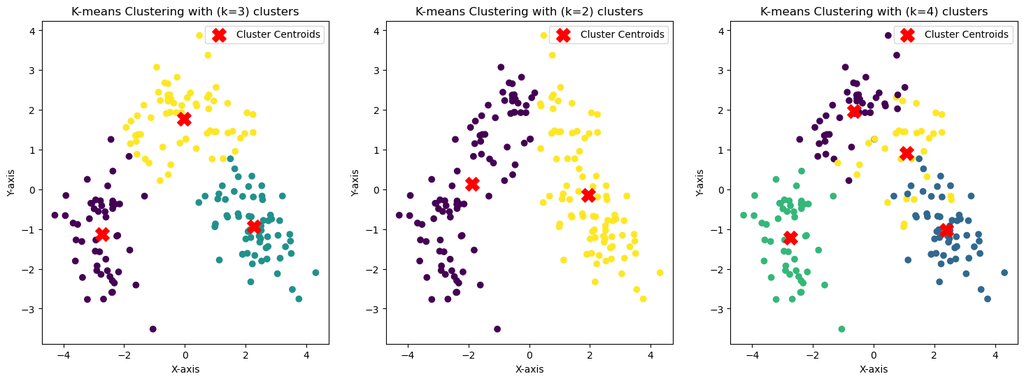

```python
fig, axes = plt.subplots(1, 3, figsize=(18, 6))

# Choosing the best 3 numbers of clusters according to silhouette score that we discovered above,
# and Visualizing them on a scatter plot of the first two principal components.

for i, n_clusters in enumerate(best_three_clusters2):
    kmeans3 = KMeans(n_clusters=n_clusters)
    cluster_labels = kmeans3.fit_predict(scaled_df_wine)
    centroids = kmeans3.cluster_centers_
    centroids_pca = pca.transform(centroids)

    # Plotting scatter plot for the each of the  dataset

    axes[i].scatter(transformed_data2[:, 0], transformed_data2[:, 1], c=cluster_labels, cmap='viridis')
    axes[i].scatter(centroids_pca[:, 0], centroids_pca[:, 1], marker='X', s=200, c='red', label='Cluster Centroids')
    axes[i].set_title(f'K-means Clustering with (k={n_clusters}) clusters')
    axes[i].set_xlabel('X-axis')
    axes[i].set_ylabel('Y-axis')
    axes[i].legend()

plt.show()
```

We have seen that 3 cluster values are the best suited for this case which are 3, 2, 4.

Transforming centroids is crucial when visualizing clusters in reduced-dimensional spaces like PCA to ensure alignment between the centroids, computed in the original feature space, and the reduced-dimensional data points. This transformation enables a consistent and accurate representation of the centroids' positions relative to the clustered data, allowing for a clearer understanding of cluster distributions and aiding in the interpretation of clustering results within the reduced space.

### Part 4 (BONUS): Filling in missing labels using clustering

In this bonus exercise, you're given a dataset with almost all of the labels are missing. This is the starting point in semi-supervised learning. Semi-supervised learning in general is beyond the scope of this course, but if you want you can learn more about it, starting e.g. on [the sklearn page for semi-supervised learning](https://scikit-learn.org/stable/modules/semi_supervised.html). **This exercise does not require researching semi-supervised learning, however.**

The dataset used in this exercise is a slightly modified version of [the seeds dataset](https://archive.ics.uci.edu/dataset/236/seeds). The features are different properties of wheat seeds. They are divided to three different classes, simply called `target1`, `target2` and `target3` here. The feature names and their data types are listed in the table below. **Use the modified dataset on Moodle, with the filename `ex3_seeds_missinglabels.csv`**

| Feature | Type |
| --- | --- |
| Area | Numeric (float) |
| Perimeter | Numeric (float) |
| Compactness | Numeric (float) |
| Length | Numeric (float) |
| Width | Numeric (float) |
| Asymmetry Coefficient | Numeric (float) |
| Length Groove | Numeric (float) |
| Target | Categorical (nominal) |

First, visualize the first two principal components of the dataset in a scatter plot, showing the labels real for data points you were given. Try to see if the labels look like they belong in what look like clusters on the plot.

Your task is to use clustering to assign labels to the rows that have an `unknown` value for their label. Do this by first clustering all of the data, and then filling in the unknown values based on which clusters the data points with known values tend to fit in. The details of how exactly you decide which rows get assigned which label are up to you - you can get creative. Describe and justify your thought process, though.

Use whichever clustering methods you prefer. You can cluster the data into 3 clusters because you have 3 known labels, but you could also try a higher number of clusters that you can then merge.

You are also given the full labels for the dataset in a separate file called `ex3_seeds_labels.csv`. Plot the real labels next to the labels that your clustering attempts predicted.

Finally, compute the adjusted Rand index for labels predicted by your clustering solutions and the real labels, and display it along the scatter plots. Rand index is a measure of similarity between two partitions of a set of elements. Adjusted Rand index is corrected for chance using the maximum and expected values of Rand index. Optionally, you can learn more about the Rand index e.g. on [the Wikipedia page for Rand index](https://en.wikipedia.org/wiki/Rand_index). Here you can simply use the `sklearn.metrics.adjusted_rand_score` method imported at the beginning of this notebook.

```python
# Loading the dataset with missing labels and real labels
data_missing_labels = pd.read_csv('ex3_seeds_missingtargets.csv')
data_real_labels = pd.read_csv('ex3_seeds_labels.csv')
data_missing_labels.head(4)
```

|  | area | perimeter | compactness | length | width | asymmetry_coef | length_groove | target |
| --- | --- | --- | --- | --- | --- | --- | --- | --- |
| 0 | 18.45 | 16.12 | 0.8921 | 6.107 | 3.769 | 2.235 | 5.794 | target2 |
| 1 | 11.41 | 12.95 | 0.8560 | 5.090 | 2.775 | 4.957 | 4.825 | target3 |
| 2 | 10.79 | 12.93 | 0.8107 | 5.317 | 2.648 | 5.462 | 5.194 | target3 |
| 3 | 18.14 | 16.12 | 0.8772 | 6.059 | 3.563 | 3.619 | 6.011 | target2 |

```python
print("Counts for labels in data_missing_labels\n",data_missing_labels["target"].value_counts())
```

```
Counts for labels in data_missing_labels
 unknown    195
target2      5
target3      5
target1      5
Name: target, dtype: int64
```

```python
print("Counts for labels in data_real_labels\n",data_real_labels["target"].value_counts())
```

```
Counts for labels in data_real_labels
 target2    70
target3    70
target1    70
Name: target, dtype: int64
```

```python
# Converting categorical target labels to numerical classes using LabelEncoder(). This is for easy clustering

label_encoder = LabelEncoder()
#data_missing_labels['target'] = label_encoder.fit_transform(data_missing_labels['target'])
#data_real_labels['target'] = label_encoder.fit_transform(data_real_labels['target'])
```

```python
# Replacing values in the DataFrame
# Mapping target1, target2, target3 as 1,2,3
value_mapping = {'target1': 1, 'target2': 2, 'target3': 3}

# Replace values in the DataFrame according to the mapping
data_missing_labels['target']= data_missing_labels['target'].replace(value_mapping)
data_real_labels['target'] = data_real_labels['target'] .replace(value_mapping)

print("Missing values are: \n",data_missing_labels['target'])
```

```
Missing values are:
 0            2
1            3
2            3
3            2
4            2
        ...
205    unknown
206    unknown
207    unknown
208    unknown
209    unknown
Name: target, Length: 210, dtype: object
```

```python
print("Real values are :\n", data_real_labels['target'])
```

```
Real values are :
 0      2
1      3
2      3
3      2
4      2
      ..
205    1
206    1
207    3
208    3
209    2
Name: target, Length: 210, dtype: int64
```

```python
# Separating features and target from the dataset with missing labels

X_missing_labels = data_missing_labels.drop('target', axis=1)
#y_missing_labels = data_missing_labels['target']

# We keep the real values for the labels in y_known_labels
y_known_labels = data_real_labels['target']
```

```python
# Visualizing the first two principal components for data points with known labels

pca2 = PCA(n_components=2)
X_pca = pca2.fit_transform(X_missing_labels)
```

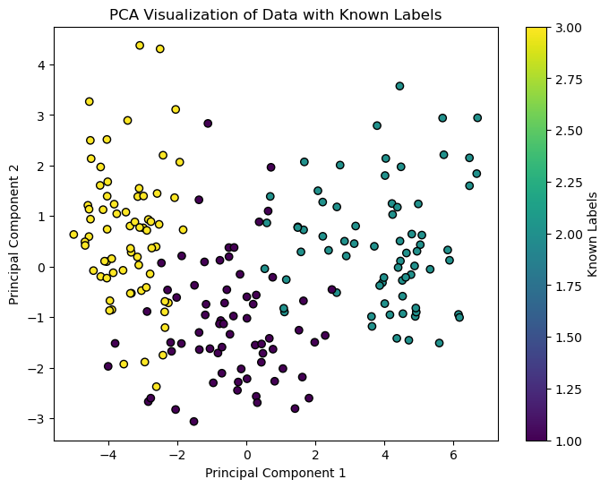

```python
plt.figure(figsize=(8, 6))
plt.scatter(X_pca[:, 0], X_pca[:, 1], c=y_known_labels, cmap='viridis', edgecolor='k')
plt.title('PCA Visualization of Data with Known Labels')
plt.xlabel('Principal Component 1')
plt.ylabel('Principal Component 2')
plt.colorbar(label='Known Labels')
plt.show()
```

```python
# Performing K-means clustering on the entire dataset
k=3
kmeans2 = KMeans(n_clusters=k, n_init=10)
kmeans2.fit(X_missing_labels, y_known_labels)
predicted_labels2 = kmeans2.predict(X_missing_labels)
```

```
Adjusted Rand Index: 0.7166198557361053
```

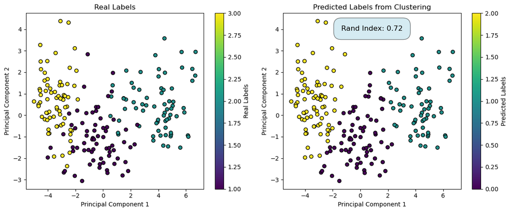

```python
# Computing Adjusted Rand Index
adjusted_rand_idx = adjusted_rand_score(y_known_labels, predicted_labels2)
print(f"Adjusted Rand Index: {adjusted_rand_idx}")

# Visualizng real labels vs predicted labels
plt.figure(figsize=(12, 5))

plt.subplot(1, 2, 1)
plt.scatter(X_pca[:, 0], X_pca[:, 1], c=y_known_labels, cmap='viridis', edgecolor='k')
plt.title('Real Labels')
plt.xlabel('Principal Component 1')
plt.ylabel('Principal Component 2')
plt.colorbar(label='Real Labels')

plt.subplot(1, 2, 2)
plt.scatter(X_pca[:, 0], X_pca[:, 1], c=predicted_labels2, cmap='viridis', edgecolor='k')
plt.title('Predicted Labels from Clustering')
plt.xlabel('Principal Component 1')
plt.ylabel('Principal Component 2')
plt.colorbar(label='Predicted Labels')
plt.annotate(f'Rand Index: {adjusted_rand_idx:.2f}',
             xy=(0.5, 0.9),
             xycoords='axes fraction',
             ha='center',
             fontsize=12,
            bbox=dict(boxstyle='round, pad=1.05', facecolor='lightblue', alpha=0.5))

plt.tight_layout()
plt.show()
```

```python
predicted_labels2=predicted_labels2+1
#predicted_labels2
```

```python
from sklearn.metrics import accuracy_score
print(" Accuracy ", accuracy_score(predicted_labels2, y_known_labels))
```

```
 Accuracy  0.8952380952380953
```

With k=3 the accuracy came out to be 89.5% and the adjusted rand_index is 71%.

We cluster the data into 3 clusters because you have 3 known labels before, but below I try a higher number of clusters that I can then merge. here, k=5. Finally, we compute the adjusted Rand index for labels predicted by our clustering solutions and the real labels, and display it along the scatter plots

```
Adjusted Rand Index: 0.5279444303602707
```

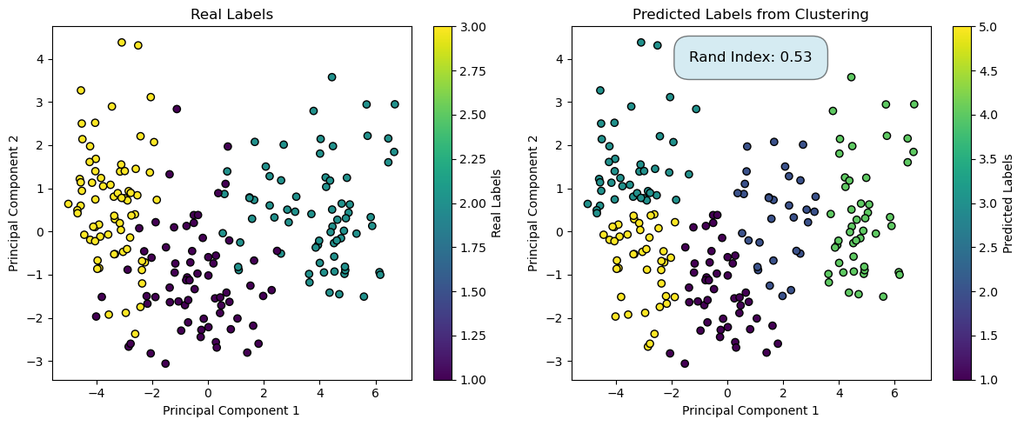

```
 Accuracy  0.5190476190476191
```

```python
# Performing clustering on the entire dataset with k=5
k=5
kmeans3 = KMeans(n_clusters=k, n_init=10)
kmeans3.fit(X_missing_labels, y_known_labels)
predicted_labels3 = kmeans3.predict(X_missing_labels)
predicted_labels3=predicted_labels3+1

# Computng Adjusted Rand Index
adjusted_rand_idx2 = adjusted_rand_score(y_known_labels, predicted_labels3)
print(f"Adjusted Rand Index: {adjusted_rand_idx2}")

# Visualizing real labels vs predicted labels
plt.figure(figsize=(12, 5))

plt.subplot(1, 2, 1)
plt.scatter(X_pca[:, 0], X_pca[:, 1], c=y_known_labels, cmap='viridis', edgecolor='k')
plt.title('Real Labels')
plt.xlabel('Principal Component 1')
plt.ylabel('Principal Component 2')
plt.colorbar(label='Real Labels')

plt.subplot(1, 2, 2)
plt.scatter(X_pca[:, 0], X_pca[:, 1], c=predicted_labels3, cmap='viridis', edgecolor='k')
plt.title('Predicted Labels from Clustering')
plt.xlabel('Principal Component 1')
plt.ylabel('Principal Component 2')
plt.colorbar(label='Predicted Labels')
plt.annotate(f'Rand Index: {adjusted_rand_idx2:.2f}',
             xy=(0.5, 0.9),
             xycoords='axes fraction',
             ha='center',
             fontsize=12,
            bbox=dict(boxstyle='round, pad=1.05', facecolor='lightblue', alpha=0.5))

plt.tight_layout()
plt.show()



from sklearn.metrics import accuracy_score
print(" Accuracy ", accuracy_score(predicted_labels3, y_known_labels))
```